# part2_hh_visualization

### Анализ вакансий с сайта hh.ru

Для анализа было загружено около 3000 вакансий за последний месяц с сайта hh.ru. Интересовали вакансии с такими ключевыми словами, как машинное обучение, анализ данных, нейронные сети, data science, data scientist, machine learning, deep learning, data analysis.

```python
import pandas as pd
import numpy as np
import itertools
from bs4 import BeautifulSoup
from sklearn.feature_extraction.text import CountVectorizer

import matplotlib.pyplot as plt
import seaborn as sns
import folium
from folium import features, plugins

sns.set_context("paper", font_scale=1.2)
```

```python
df = pd.read_csv('data/hh_data.csv', sep='\t')
print(df.shape)
df.head(3)
```

```
(2960, 22)
```

|  | accept_handicapped | address_city | address_lat | address_lng | description | employer_name | employment | experience | has_branded_description | has_test | ... | metro_stations | name | premium | published_at | salary_currency | salary_from | salary_gross | salary_to | schedule | type |
| --- | --- | --- | --- | --- | --- | --- | --- | --- | --- | --- | --- | --- | --- | --- | --- | --- | --- | --- | --- | --- | --- |
| 0 | 0.0 | Санкт-Петербург | 59.999921 | 30.256418 | Компания Umbrellio занимается разработкой собс... | Амбреллио | full | between1And3 | 0.0 | 0.0 | ... | [{'lat': 60.008591, 'station_name': 'Комендант... | Data scientist | 0.0 | 2018-09-30T12:27:49+0300 | NaN | NaN | NaN | NaN | fullDay | open |
| 1 | 0.0 | Москва | 55.796273 | 37.599687 | Our team is building the Data platform to enab... | NVIDIA | full | between3And6 | 0.0 | 0.0 | ... | [{'station_id': '10.185', 'station_name': 'Мар... | Chief Data Scientist | 0.0 | 2018-09-30T17:38:04+0300 | NaN | NaN | NaN | NaN | fullDay | open |
| 2 | 0.0 | Москва | 55.699837 | 37.623645 | Align Technology – один из международных лидер... | Align Technology Inc | probation | noExperience | 0.0 | 0.0 | ... | [{'station_name': 'Тульская', 'station_id': '9... | Machine Learning Intern | 0.0 | 2018-09-30T13:23:03+0300 | NaN | NaN | NaN | NaN | flexible | open |

3 rows × 22 columns

```python
# сразу удалим нерелевантные вакансии (практически все от одной компании)
df = df.drop(df[df.name == 'Программист 1С'].index)
df.shape
```

```
(2900, 22)
```

В некоторых вакансиях работодателем было заполнено поле "ключевые навыки". Воспользуемся этим и составим словарь важных навыков аналитика. В дальнейшем с помощью этого словаря можно будет извлечь основные требования из описания вакансии.

```python
def create_vocab(text):
    vocab = []
    for i in range(0, len(text)):
        vocab.append(text[i].split(','))

    vocab = list(itertools.chain(*vocab))
    vocab = [skill for skill in vocab if '1C' not in skill] # eng
    vocab = [skill for skill in vocab if '1С' not in skill] # rus
    vocab = [skill.replace('(', ' ').replace(')', ' ').replace(';', ' ').\
                  strip().lower() for skill in vocab]

    skills, counts = np.unique(vocab, return_counts=True)

    vocab = pd.DataFrame({'skill':skills, 'count':counts})
    vocab.drop(vocab[vocab.skill == ''].index, inplace=True)
    vocab['words_count'] = vocab['skill'].apply(lambda skill: len(skill.split(' ')))
    return vocab
```

```python
skills_vocab = create_vocab(df['key_skills'].dropna().values)
skills_vocab = skills_vocab[skills_vocab.words_count < 6].sort_values('count', ascending=False).iloc[:300, :]
skills_vocab.sort_values('count', ascending=False).head()
```

|  | skill | count | words_count |
| --- | --- | --- | --- |
| 536 | python | 300 | 1 |
| 661 | sql | 207 | 1 |
| 437 | ms excel | 114 | 2 |
| 395 | machine learning | 111 | 2 |
| 89 | big data | 101 | 2 |

Извлечем ключевые навыки из основного текста вакансии:

```python
def update_description(text):
    return text.lower().replace('.', ' ').\
            replace(',', ' ').replace(';', ' ').\
            replace('(', ' ').replace(')', ' ').\
            replace('/', ' ').replace('\\', ' ')

df['description'] = df['description'].apply(update_description)
```

```python
from sklearn.feature_extraction.text import CountVectorizer

vectorizer = CountVectorizer(vocabulary=skills_vocab['skill'].values, \
                             ngram_range=(1, 5), token_pattern=u'\\b\\w+\\b')

X = vectorizer.fit_transform(df['description'].values).toarray()
skills_from_description = []

for vacancy_index in np.arange(0, df.shape[0]):
    indices = X[vacancy_index].nonzero()[0]
    skills = np.array(vectorizer.get_feature_names())[indices]
    skills_from_description.append(','.join([str(x) for x in skills]))

df['skills_from_description'] = skills_from_description
```

И объединим требуемые навыки из обеих групп: тех, которые указал сам работодатель и тех, которые получилось извлечь из текста. Далее будем использовать именно эту колонку для анализа.

```python
def get_skills(row):
    key_skills = row[0]
    skills_from_description = row[1]

    if pd.notnull(key_skills):
        key_skills = [s.lower().strip() for s in key_skills.split(',')]
    else:
        key_skills = []

    skills_from_description = skills_from_description.split(',')

    return ','.join(s for s in set(key_skills + skills_from_description))

df['skills'] = df[['key_skills', 'skills_from_description']].apply(get_skills, axis=1)
# количество требуемых навыков
df['skills_count'] = df['skills'].apply(lambda s: len(s.split(',')))
```

В некоторых вакансиях зарплата была указана в валюте, отличной от рублей, поэтому переведем эти значения по текущему курсу:

```python
import xml.etree.ElementTree
import requests

cbr_link = 'http://www.cbr.ru/scripts/XML_daily.asp'
cbr_data = requests.get(cbr_link).text
root = xml.etree.ElementTree.fromstring(cbr_data)

current_currency = {child[1].text:float(child[4].text.replace(',', '.')) for child in root}
```

```python
def convert_to_rub(row):
    value = row[0]
    currency_code = row[1]

    if (currency_code == 'RUR') | np.isnan(value):
        return value
    else:
        return current_currency[currency_code]*value

df['salary_currency'] = df['salary_currency'].apply(lambda v: 'BYN' if v == 'BYR' else v)
df['salary_from'] = df[['salary_from', 'salary_currency']].apply(convert_to_rub, axis=1)
df['salary_to'] = df[['salary_to', 'salary_currency']].apply(convert_to_rub, axis=1)
```

Лишь небольшая часть вакансий содержит полную информацию о зарплатной вилке. В некоторых же указано либо значения ОТ, либо ДО. Для того чтобы не исключать эти данные из анализа, их можно дополнить. Для этого можно посчитать на сколько в среднем отличаются крайние значения ОТ и ДО на тех вакансиях, где есть полная информация по зарплате.

```python
df_coeff = df[pd.notnull(df['salary_from']) & pd.notnull(df['salary_to'])]
from_values = df_coeff['salary_from'].values
to_values = df_coeff['salary_to'].values
coeff = (to_values/from_values).mean()
coeff
```

```
1.6170338677527032
```

```python
def update_salary_from(row):
    salary_from, salary_to = row[0], row[1]

    if pd.isnull(salary_from) & pd.notnull(salary_to):
        salary_from = salary_to/coeff

    return salary_from

def update_salary_to(row):
    salary_from, salary_to = row[0], row[1]

    if pd.notnull(salary_from) & pd.isnull(salary_to):
        salary_to = salary_from*coeff

    return salary_to

def get_salary_mean(row):
    if pd.notnull(row[0]) & pd.notnull(row[1]):
        return np.mean([row[0], row[1]])
```

```python
df['salary_to'] = df[['salary_from', 'salary_to']].apply(update_salary_to, axis=1)
df['salary_from'] = df[['salary_from', 'salary_to']].apply(update_salary_from, axis=1)
df['salary_mean'] = df[['salary_from', 'salary_to']].apply(get_salary_mean, axis=1)
```

Посмотрим на картинки.

**Как часто публикуется информация о зарплате?**

```python
df['salary_info'] = df['salary_mean'].apply(lambda s: 'yes' if pd.notnull(s) else 'no')
```

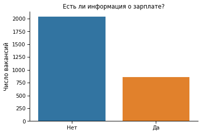

```python
fig, axes = plt.subplots(figsize=(6, 4))
sns.despine()

sns.countplot(x='salary_info', data=df, ax=axes)
axes.set_xticklabels(['Нет', 'Да'])
axes.set_title('Есть ли информация о зарплате?')
axes.set(xlabel='', ylabel='Число вакансий');
```

**В каких городах больше всего вакансий?**

```python
cities = ['Москва', 'Санкт-Петербург', 'Минск', 'Киев']
df['city_region'] = df['address_city'].apply(lambda c: c if c in cities else 'Регионы')
data = df['city_region'].value_counts()
```

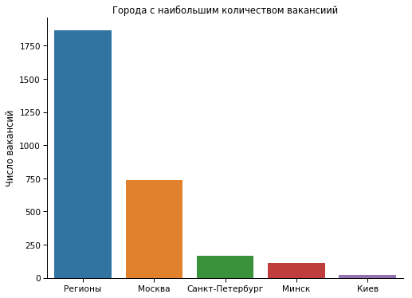

```python
fig, axes = plt.subplots(figsize=(8, 6))
sns.despine()

sns.barplot(x=data.index, y=data.values)
axes.set_title('Города с наибольшим количеством вакансиий')
axes.set(xlabel='', ylabel='Число вакансий');
```

В принципе, ожидаемый результат: HeadHunter ориентирован на российский рынок. Больше всего работы в Москве и Санкт-Петербурге, остальные распределены по всей стране в разных городах. Немного вакансий есть в Белоруссии и Украине.

**С каким опытом работы чаще всего ищут на hh?**

```python
data = df['experience'].value_counts()
```

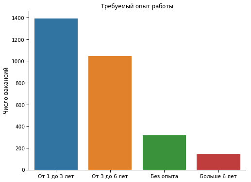

```python
fig, axes = plt.subplots(figsize=(8, 6))
sns.despine()

sns.barplot(x=data.index, y=data.values)
axes.set_xticklabels(['От 1 до 3 лет', 'От 3 до 6 лет', 'Без опыта', 'Больше 6 лет'])
axes.set_title('Требуемый опыт работы')
axes.set(xlabel='', ylabel='Число вакансий');
```

**Какой график работы?**

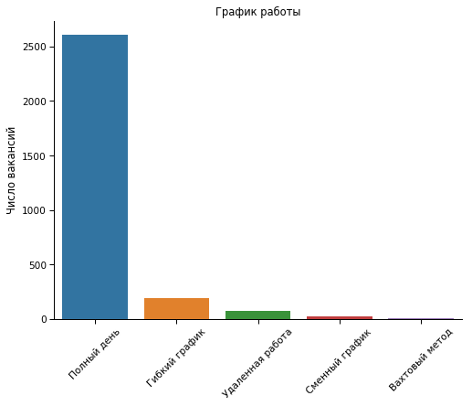

```python
fig, axes = plt.subplots(figsize=(8, 6))
sns.despine()

sns.countplot(x='schedule', data=df, ax=axes);
axes.set_xticklabels(['Полный день', 'Гибкий график', 'Удаленная работа', \
                      'Cменный график', 'Вахтовый метод'], rotation=45)
axes.set_title('График работы')
axes.set(xlabel='', ylabel='Число вакансий');
```

Странно было увидеть здесь сменный график и вахтовый метод. Есть немного работы, не требующей присутствия в офисе. Может быть шансов работать из дома или с гибким графиком больше у опытных сотрудников? Или компании из регионов готовы нанимать людей из других городов на удаленную работу?

**График работы в зависимости от региона**

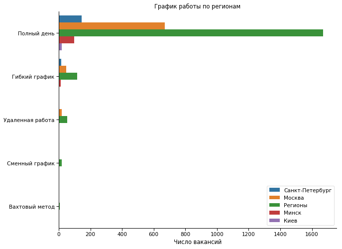

```python
fig, axes = plt.subplots(figsize=(10, 8))
sns.despine()

g = sns.countplot(y='schedule', hue='city_region', data=df, ax=axes)
g.legend(loc='lower right')
axes.set_yticklabels(['Полный день', 'Гибкий график', 'Удаленная работа', \
                      'Cменный график', 'Вахтовый метод'])
axes.set_title('График работы по регионам')
axes.set(ylabel='', xlabel='Число вакансий');
```

**График работы в зависимости от опыта**

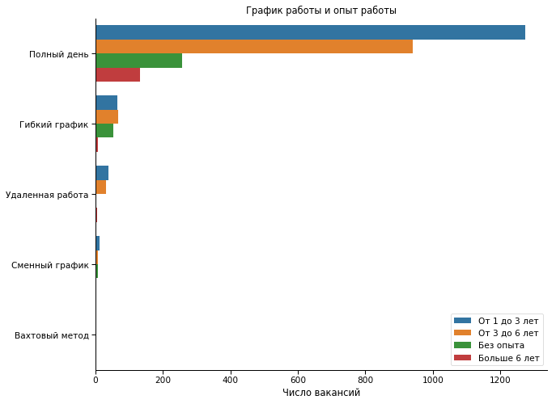

```python
fig, axes = plt.subplots(figsize=(10, 8))
sns.despine()

g = sns.countplot(y='schedule', hue='experience', data=df, ax=axes)
g.legend(('От 1 до 3 лет', 'От 3 до 6 лет', 'Без опыта', 'Больше 6 лет'), loc='lower right')
axes.set_yticklabels(['Полный день', 'Гибкий график', 'Удаленная работа', \
                      'Cменный график', 'Вахтовый метод'])
axes.set_title('График работы и опыт работы')
axes.set(ylabel='', xlabel='Число вакансий');
```

Как изменяется зарплата в зависимости от опыта работы, графика и города?

**Распределение зарплаты в зависимости от опыта и локации**

```python
data_salary = df[pd.notnull(df['salary_from']) & pd.notnull(df['salary_to'])]
```

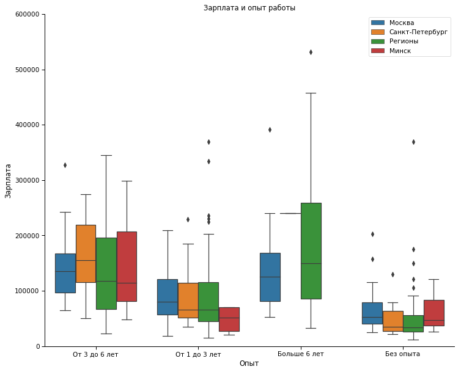

```python
fig, axes = plt.subplots(figsize=(12, 10))
sns.despine()

regions = ['Москва', 'Санкт-Петербург', 'Минск', 'Регионы']
data = data_salary[data_salary.city_region.isin(regions)]
g = sns.boxplot('experience', 'salary_mean', hue='city_region', data=data)
g.legend(loc='upper right')
plt.ylim(0, 600000)
axes.set_xticklabels(['От 3 до 6 лет', 'От 1 до 3 лет', 'Больше 6 лет', 'Без опыта'])
axes.set_title('Зарплата и опыт работы')
axes.set(ylabel='Зарплата', xlabel='Опыт');
```

Видно, что работу все-таки лучше искать в Москве. Здесь ее могут найти люди с любым стажем. Особенно хорошо начинать в столице, если опыта нет или он до 3х лет, а потом переехать на север в Санкт-Петербург. Интересно отметить, что в Санкт-Петербурге и Минске мало вакансий для людей с большим опытом.

**Зарплата в зависимости от графика работы и локации**

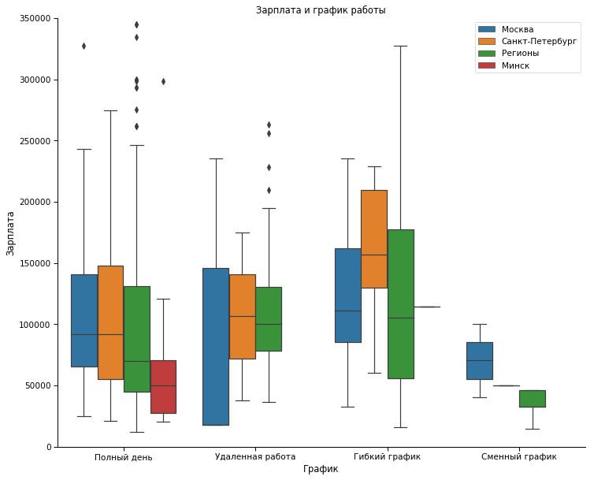

```python
fig, axes = plt.subplots(figsize=(12, 10))
sns.despine()

regions = ['Москва', 'Санкт-Петербург', 'Минск', 'Регионы']
schedules = ['fullDay', 'remote', 'flexible', 'shift']
data = data_salary[data_salary.schedule.isin(schedules) & data_salary.city_region.isin(regions)]
g = sns.boxplot('schedule', 'salary_mean', hue='city_region', data=data)
g.legend(loc='upper right')
axes.set_xticklabels(['Полный день', 'Удаленная работа', 'Гибкий график', 'Cменный график'])
axes.set_title('Зарплата и график работы')
axes.set(ylabel='Зарплата', xlabel='График');
plt.ylim(0, 350000);
```

Если график принципиален, то поиски удаленной работы или с гибким графиком лучше начать в Санкт-Петербурге.

**Число ключевых навыков в описании вакансии**

Чего ждут работодатели от своих сотрудников? Какие и как много требований и за какие деньги?

Можно выдвинуть предположение, что от сотрудника с большим опытом будут ждать большего, соответственно, количество требуемых навыков в описании вакансии будет в среднем больше. Правда ли, много знаешь, больше получаешь? :)

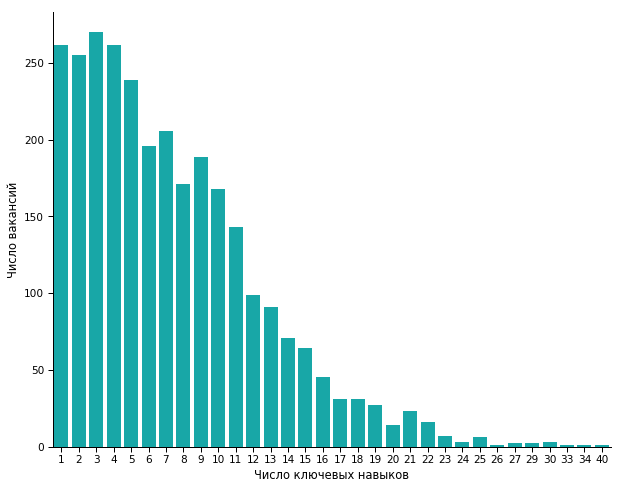

```python
fig, axes = plt.subplots(figsize=(10, 8))
sns.despine()

sns.countplot(x="skills_count", data=df, color="c");
axes.set(xlabel='Число ключевых навыков', ylabel='Число вакансий');
```

**Число ключевых навыков в описании вакансии и опыт работы**

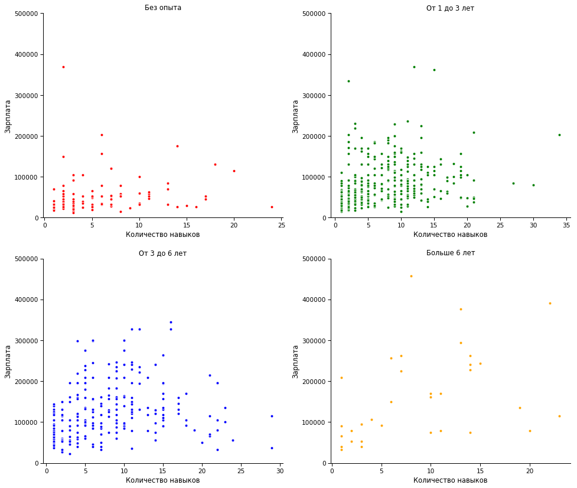

```python
fig, axes = plt.subplots(nrows=2, ncols=2, figsize=(16, 14))
sns.despine()

experiences = {'noExperience': 'Без опыта', 'between1And3': 'От 1 до 3 лет', \
               'between3And6': 'От 3 до 6 лет', 'moreThan6': 'Больше 6 лет'}
colors = ['red', 'green', 'blue', 'orange']

for experience, ax, color in zip(experiences.keys(), axes.ravel(), colors):
    data = data_salary[data_salary.experience == experience]
    g = sns.scatterplot('skills_count', 'salary_mean', data=data, ax=ax, color=color)
    ax.set_title(experiences[experience])
    ax.set(ylabel='Зарплата', xlabel='Количество навыков');
    ax.set_ylim(0, 500000)
plt.show()
```

В целом, мое предположение о связи числа навыков в вакансии и зарплате не нашли подтверждений. Какую-то связь можно отметить для очень опытных людей, но там мало данных. Еще можно заметить, что для сотрудников без опыта количество требований ниже, чем у остальных. И скорее всего, это будут какие-нибудь навыки типа: умение работать в команде, обучаемость, знание одного языка программирования.

**Ключевые навыки для разного опыта**

Какие знания и умения требуются от работников? Как они изменяются по мере накопления опыта?

```python
import itertools

def get_most_common_skills(skills, n=10):
    key_skills = []

    for i in range(0, len(skills)):
        key_skills.append(skills[i].split(','))

    key_skills = [skill.strip() for skill in list(itertools.chain(*key_skills))]
    skills, counts = np.unique(key_skills, return_counts=True)
    indices = counts.argsort()[::-1][:n]
    return pd.DataFrame({'skill': skills[indices], 'count': counts[indices]})
```

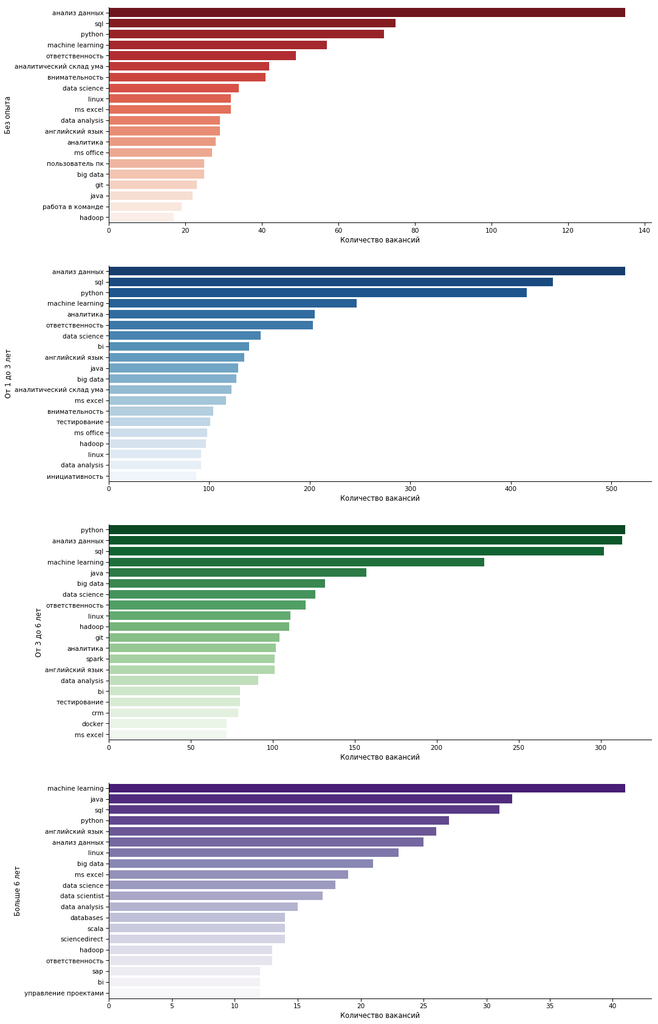

```python
fig, axes = plt.subplots(nrows=4, figsize=(16, 30))
sns.despine()

experiences = {'noExperience': 'Без опыта', 'between1And3': 'От 1 до 3 лет', \
               'between3And6': 'От 3 до 6 лет', 'moreThan6': 'Больше 6 лет'}
colors = ['Reds_r', 'Blues_r', 'Greens_r', 'Purples_r']

for experience, ax, color in zip(experiences.keys(), axes.ravel(), colors):
    data = get_most_common_skills(df[df.experience == experience]['skills'].values, 20)
    sns.barplot('count', 'skill', data=data, ax=ax, palette=color)
    ax.set(ylabel=experiences[experience], xlabel='Количество вакансий');
```

Видно, что куда бы не отправлял резюме, про Python и SQL обязательно стоит написать. Интересно, что чем опытнее требуется сотрудник, тем больший сдвиг в сторону бигдаты: java, big data, hadoop, spark. Для очень опытных людей появляется навык "управление проектами", а вот ответственность опускается немного ниже :)

**Географическое распределение вакансий**

Посмотрим на географию вакансий в Москве.

```python
data_moscow = df[(df.city_region == 'Москва')]
kremlin = [55.750730, 37.617322]
```

```python
vacancy_map = folium.Map(location=kremlin, zoom_start=10)
mc = plugins.MarkerCluster()

for i in range(0, len(data_moscow)):
    mk = features.Marker([data_moscow.iloc[i, :]['address_lat'], data_moscow.iloc[i, :]['address_lng']], \
                  popup=folium.Popup(data_moscow.iloc[i, :]['employer_name'], parse_html=True))
    mc.add_child(mk)

vacancy_map.add_child(mc)
```

[interactive chart not shown]

```python
vacancy_map = folium.Map(location=kremlin, zoom_start=10)

data = [[x[0], x[1], 1] for x in np.array(data_moscow[['address_lat', 'address_lng']])]

plugins.HeatMap(data, radius = 20).add_to(vacancy_map)
vacancy_map
```

[interactive chart not shown]

Кажется, что с выбором жилья на Юго-Востоке Москвы я ошиблась :)